# Célula População

2025-01-31

# Célula População

A população é fundamental para a compreensão da realidade social de qualquer território. Ela representa o denominador básico de todos os indicadores sociais, econômicos e ambientais. Nesse sentido, é indispensável conhecer a estrutura e dinâmica populacional para avaliar corretamente a distribuição de recursos, para a formulação de políticas públicas e para o planejamento urbano adequado. O objetivo principal dessa célula é a sistematizar e espacializar estimativas da população por município, desagregada por idade, sexo e situação de domicílio.

# A mesorregião Norte Fluminense

## População Absoluta

```r
pop_total_nf<-read_rds(here('data/processed','pop_total_nf.rds'))

temp_numeric<-list(
    pop1970=pop_total_nf[pop_total_nf$sit=='Total',"1970"]%>%pull(),
    pop2010=pop_total_nf[pop_total_nf$sit=='Total',"2010"]%>%pull(),
    pop2022=pop_total_nf[pop_total_nf$sit=='Total',"2022"]%>%pull(),
    urban2000=pop_total_nf[pop_total_nf$sit=='Urbana',"2000"]%>%pull(),
    urban2010=pop_total_nf[pop_total_nf$sit=='Urbana',"2010"]%>%pull(),
    rur2000=pop_total_nf[pop_total_nf$sit=='Rural',"2000"]%>%pull(),
    rur2010=pop_total_nf[pop_total_nf$sit=='Rural',"2010"]%>%pull()
  )
temp_text<-list(
    pop1970=format(temp_numeric$pop1970,big.mark = ".", decimal.mark = ",", nsmall = 0),
    pop2022=format(temp_numeric$pop2022,big.mark = ".", decimal.mark = ",", nsmall = 0)
)

temp_diff<-list(
  diff_1=temp_numeric$pop2022-temp_numeric$pop1970,
  diff_2=temp_numeric$pop2022-temp_numeric$pop2010,
  diff_3=temp_numeric$urban2010-temp_numeric$urban2000,
  diff_4=temp_numeric$rur2010-temp_numeric$rur2000
)

temp_diff_text<-list(
  diff_1=format(temp_diff$diff_1,big.mark = ".", decimal.mark = ",", nsmall = 0),
  diff_2=format(temp_diff$diff_2,big.mark = ".", decimal.mark = ",", nsmall = 0),
  diff_3=format(temp_diff$diff_3,big.mark = ".", decimal.mark = ",", nsmall = 0),
  diff_4=format(temp_diff$diff_4,big.mark = ".", decimal.mark = ",", nsmall = 0)
)


pop_total_nf%>%
   mutate(across(`1970`:`2022`,
                 ~ comma(.x, decimal.mark = ",", big.mark = ".", accuracy = 1)))%>%
  kbl() %>%
  kable_paper(full_width = F) %>%
  footnote(general = "Fonte: Censos Demográficos [@ibge2023]",
           general_title = "")
```

| sit | 1970 | 1980 | 1991 | 2000 | 2010 | 2022 |
| --- | --- | --- | --- | --- | --- | --- |
| Urbana | 244.730 | 304.569 | 484.346 | 594.713 | 748.680 | NA |
| Rural | 241.716 | 223.021 | 127.230 | 104.070 | 100.835 | NA |
| Total | 486.446 | 527.590 | 611.576 | 698.783 | 849.515 | 920.826 |

Fonte: Censos Demográficos (IBGE, 2023)

Um dos fatores que influenciou a alteração do balanço entre as populações urbana e rural foi a migração externa, que agregou população em núcleos urbanos da MRNF. A partir dos dados coletados, observou-se um expressivo crescimento do número de migrantes na MRNF. De acordo com o Censo Demográfico, residiam na região no ano de 2000, 15.328 imigrantes. Já o Censo de 2010 apontou 111.200 habitantes residentes na mesorregião naturais de outro estado ou de outras regiões do Estado do Rio de Janeiro, um acréscimo de 95.872 imigrantes nesse período. Esse fenômeno foi especialmente notável no município de Macaé, onde uma parte considerável desses imigrantes passou a residir. Cerca de 63% do número total de habitantes acrescidos entre 2000 e 2010 foram imigrantes.

## Crescimento Populacional

```r
rm_temp()
growthratio_brrjnf<-read_rds(here('data/processed','growthratio_brrjnf.rds'))%>%
  filter(ut_co %in% c(1,33,3302,3302403))

pop_brrjnf<-read_rds(here('data/processed','pop_brrjnf.rds'))%>%
  filter(ut_co %in% c(1,33,3302,3302403))

temp_numeric<-list(
    pop2000_macae=pop_brrjnf%>%
      filter(ut_co==3302403)%>%
      select(total2000)%>%
      pull(),
   pop2010_macae=pop_brrjnf%>%
      filter(ut_co==3302403)%>%
      select(total2010)%>%
      pull(),
   gr2010_2022_nf=growthratio_brrjnf%>%
     filter(ut_co==3302)%>%
     select(gr2010_2022)%>%
     pull(),
   gr2010_2022_br=growthratio_brrjnf%>%
     filter(ut_co==1)%>%
     select(gr2010_2022)%>%
     pull(),
   gr2010_2022_rj=growthratio_brrjnf%>%
     filter(ut_co==33)%>%
     select(gr2010_2022)%>%
     pull()
  )

temp_text<-list(
    pop2000_macae=format(temp_numeric$pop2000_macae,
                         big.mark = ".", decimal.mark = ",", nsmall = 0),
    pop2010_macae=format(temp_numeric$pop2010_macae,
                         big.mark = ".", decimal.mark = ",", nsmall = 0),
    gr2010_2022_rj=percent(temp_numeric$gr2010_2022_rj,
                                  big.mark = ".",
                                  decimal.mark = ",",
                                  accuracy=0.01),
    gr2010_2022_nf=percent(temp_numeric$gr2010_2022_nf,
                                  big.mark = ".",
                                  decimal.mark = ",",
                                  accuracy=0.01),
    gr2010_2022_br=percent(temp_numeric$gr2010_2022_br,
                                  big.mark = ".",
                                  decimal.mark = ",",
                                  accuracy=0.01)
    )

temp_diff<-list(
  diff_1=temp_numeric$pop2010_macae-temp_numeric$pop2000_macae
)

temp_diff_text<-list(
  diff_1=format(temp_diff$diff_1,big.mark = ".", decimal.mark = ",", nsmall = 0)
)


growthratio_brrjnf %>%
  filter(ut_co != 3302403) %>%
  select(-ut_co) %>%
  pivot_longer(cols = starts_with("gr"),
               names_to = "Período",
               values_to = "Taxa de Crescimento") %>%
  mutate(Período = str_remove(Período, "gr") %>%
           str_replace("_", "-")) %>%
  pivot_wider(names_from = ut, values_from = "Taxa de Crescimento") %>%
  mutate(across(2:4,~percent_format(scale=100,
                                    big.mark = ".",
                                    decimal.mark = ",")(.)))%>%
  arrange(Período)%>%
  select(Período, `Norte Fluminense`, `Rio de Janeiro`, Brasil)%>%
  kbl(format = "html", table.attr = "border='1' cellspacing='0' cellpadding='5'") %>%
  kable_paper(full_width = F) %>%
  footnote(general = "Fonte: Censos Demográficos (IBGE, 2023)",
           general_title = "")
```

| Período | Norte Fluminense | Rio de Janeiro | Brasil |
| --- | --- | --- | --- |
| 1970-1980 | 0,81% | 2,274% | 2,45% |
| 1980-1991 | 1,34% | 1,145% | 1,91% |
| 1991-2000 | 1,50% | 1,308% | 1,64% |
| 2000-2010 | 1,95% | 1,053% | 1,16% |
| 2010-2022 | 0,67% | 0,034% | 0,52% |

Fonte: Censos Demográficos (IBGE, 2023)

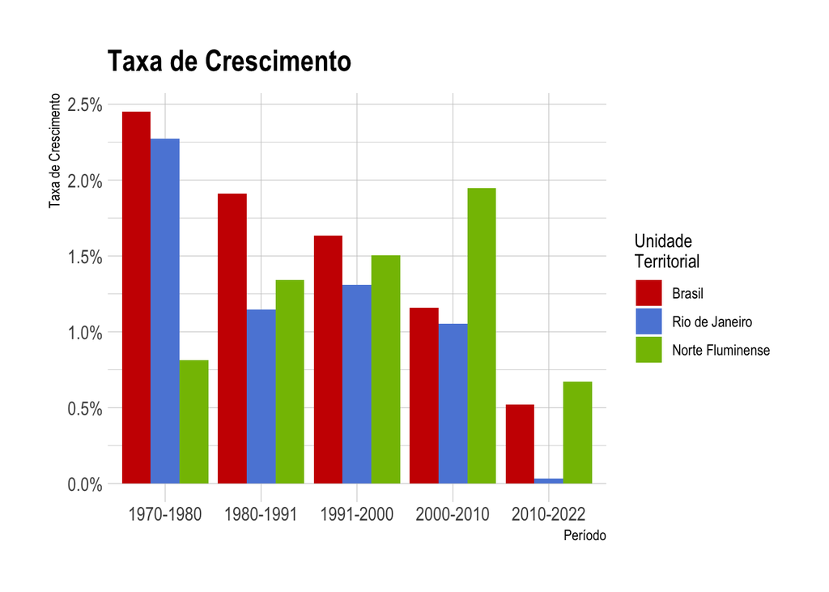

```r
temp_plotdf<-growthratio_brrjnf%>%
  filter(ut_co != 3302403)%>%
  pivot_longer(cols=c(gr2010_2022,gr2000_2010,gr1991_2000,gr1980_1991,gr1970_1980),
               names_to='periodo',
               values_to='taxa')%>%
  mutate(periodo=str_replace(periodo,"_","-"),
         periodo=str_replace(periodo,"gr",""),
         ut=factor(ut_co,levels=c(1,33,3302),
                   labels=c('Brasil','Rio de Janeiro','Norte Fluminense')))

temp_gg<-ggplot(temp_plotdf,aes(x=periodo,y=taxa,fill = ut))+
  geom_col(position='dodge')+
  labs(title='Taxa de Crescimento',
       x='Período')+
  scale_fill_startrek(name='Unidade\nTerritorial')+
  scale_y_continuous(labels = percent_format(scale=100),name='Taxa de Crescimento')+
  theme_ipsum()

temp_gg
```

A população da região aumentou a taxas mais relevantes a partir da década de **1980**, em decorrência das atividades de **exploração e produção de petróleo na Bacia de Campos**. Esse fenômeno contribuiu significativamente para a migração de pessoas para a região, com foco principalmente em **Macaé**, que viu sua população crescer de 132.461 habitantes em 2000 para 206.728 em 2010, registrando um acréscimo de 74.267 habitantes.

O crescimento populacional da região no período entre 2010 e 2022 (0,67%) foi similar ao crescimento da população brasileira (0,52%). De forma comparativa, a região cresceu em um ritmo forte, se comparado com a população do estado do Rio de Janeiro, cujo crescimento foi próximo a zero (0,03%). Esse crescimento expressivo da população na região é um reflexo da imigração, seja em busca de trabalho ou por familiares acompanhando um migrante principal. Adiconalmente, o crescimento também é consequencia do efeito indireto da imigração que são os filhos dos migrantes que nasceram no destino e que não são captados como migrantes pelos censos.

## Estrutura Etária

As pirâmides etárias representam a população relativa de homens e mulheres, geralmente em grupos etários quinquenais, em um determinado momento. Sua representação é um gráfico de barras distribuídas à direita e à esquerda de um eixo vertical central, com os homens representados nas barras à esquerda e as mulheres à direita. No eixo das abcissas, é representada a proporção de pessoas, e no eixo das ordenadas, os grupos de idades. A partir da análise da base e da forma das pirâmides, é possível fazer inferências sobre o crescimento populacional, comportamento da natalidade, mortalidade e migração.

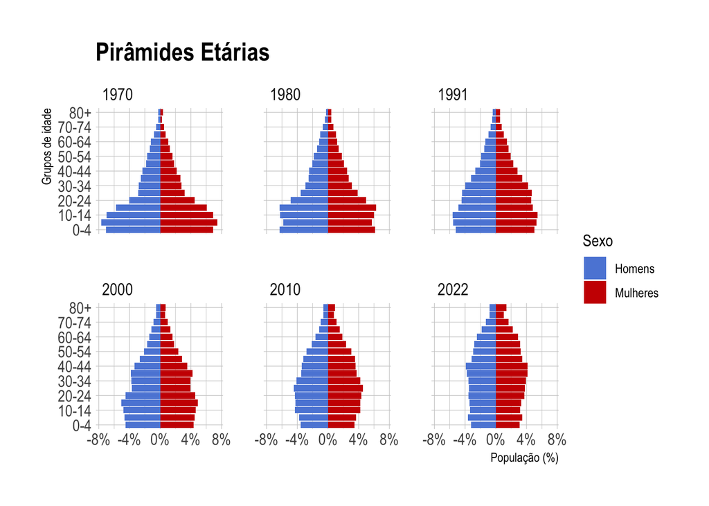

```r
rm_temp()
pop_grid_nf<-read_rds(here('data/processed','pop_grid_nf.rds'))
dtb_nf<-read_rds(here('data/processed','dtb_nf.rds'))

temp_ggdf<-pop_grid_nf%>%
  group_by(ano)%>%
  mutate(total=sum(pop,na.rm = TRUE))%>%
  ungroup()%>%
  mutate(rel=if_else(sex=='Homens',-pop/total,pop/total))

ggplot(data=temp_ggdf,aes(x=grid,y=rel,fill=sex))+
  geom_bar(stat='identity',position='stack')+
  coord_flip()+
  facet_wrap(~ano)+
  labs(title='Pirâmides Etárias',x= 'Grupos de idade')+
  scale_fill_manual(name='Sexo',values=rev(pal_startrek()(2)))+
  scale_y_continuous(labels = percent_format(scale=100),
                     name='População (%)')+
  theme_ipsum()+
  scale_x_discrete(
    breaks = levels(temp_ggdf$grid)[seq(1, length(levels(temp_ggdf$grid)), by = 2)])
```

No caso das pirâmides etárias que representam o padrão por sexo e idade da região Norte Fluminense, nota-se que, em 1970, havia uma grande proporção de jovens abaixo de 20 anos, com uma forte diminuição relativa da população a partir dessa faixa etária. Como os maiores fluxos migratórios estão associados à migração em busca de trabalho e renda, a migração tende a ser seletiva por idade. No caso da região Norte Fluminense, a menor proporção de pessoas com mais de 30 anos pode ser associada à emigração de jovens para fora da região até meados da década de 1980. Em 1980, já se nota um pequeno arrefecimento da emigração observada na década anterior, mas é a partir do Censo de 1991 que a região passa a ser considerada receptora de pessoas em idades produtivas. Muito provavelmente, em função do aquecimento econômico na região entre as décadas de 1980 e 2000, essa imigração foi certamente associada à criação de novos postos de trabalho nas cidades de destino, especialmente em Macaé.

Adicionalmente, a análise das bases de todas as pirâmides etárias indica uma progressiva queda na fecundidade e mortalidade, refletindo o avanço da transição demográfica observado em praticamente todas as regiões brasileiras. Apesar de já ser perceptível um ligeiro envelhecimento da população em 2010 e 2022, o padrão etário ainda se concentrava nas idades mais jovens. Nesse contexto, em comparação com outras regiões do país, a região Norte Fluminense, mais em função da entrada de imigrantes do que dos efeitos da transição demográfica, possuía uma alta proporção de população em idade ativa em relação à população de crianças e idosos. Nesse sentido, é possível afirmar que a região se encontra diante de uma janela de oportunidades proporcionada por um bônus demográfico devido à forte entrada de migrantes em idade ativa e uma maior proporção de pessoas jovens na população.

# Os municípios da Região Norte Fluminense

```r
pop_brrjnf<-read_rds(here('data/processed','pop_brrjnf.rds'))

temp_text<-list(
  prop_macaeecampos=percent((pop_brrjnf%>%
                               filter(ut_co %in% c(3302403,3301009))%>%
                               select(total2022)%>%
                               pull()%>%
                               sum())/(pop_brrjnf%>%
                                         filter(ut_co %in% c(3302))%>%
                                         select(total2022)%>%
                                         pull()),
                            big.mark = ".", decimal.mark = ",", accuracy =0.01),
  prop_campos70= percent((pop_brrjnf%>%
                            filter(ut_co %in% c(3301009))%>%
                            select(total1970)%>%
                            pull()%>%
                            sum())/(pop_brrjnf%>%
                                      filter(ut_co %in% c(3302))%>%
                                      select(total1970)%>%
                                      pull()),
                         big.mark = ".", decimal.mark = ",", accuracy =0.01),
  prop_campos22=percent((pop_brrjnf%>%
                           filter(ut_co %in% c(3301009))%>%
                           select(total2022)%>%
                           pull()%>%
                           sum())/(pop_brrjnf%>%
                                     filter(ut_co %in% c(3302))%>%
                                     select(total2022)%>%
                                     pull()),
                        big.mark = ".", decimal.mark = ",", accuracy =0.01),
  prop_macae70=percent((pop_brrjnf%>%
                          filter(ut_co %in% c(3302403))%>%
                          select(total1970)%>%
                          pull()%>%
                          sum())/(pop_brrjnf%>%
                                    filter(ut_co %in% c(3302))%>%
                                    select(total1970)%>%
                                    pull()),
                       big.mark = ".", decimal.mark = ",", accuracy =0.01),
  prop_macae22=percent((pop_brrjnf%>%
                          filter(ut_co %in% c(3302403))%>%
                          select(total2022)%>%
                          pull()%>%
                          sum())/(pop_brrjnf%>%
                                    filter(ut_co %in% c(3302))%>%
                                    select(total2022)%>%
                                    pull()),
                       big.mark = ".", decimal.mark = ",", accuracy =0.01)
)

pop_brrjnf%>%
  rename(`Unidade Territorial`=ut)%>%
  filter(ut_co %in% c(1,33,3302,dtb_nf$munic_co))%>%
  select(`Unidade Territorial`,total1970,total1980,total1991,total2000,total2010,total2022)%>%
  rename(`1970`=total1970,
         `1980`=total1980,
         `1991`=total1991,
         `2000`=total2000,
         `2010`=total2010,
         `2022`=total2022)%>%
  mutate(ordem=case_when(
    `Unidade Territorial`=='Brasil'~4,
    `Unidade Territorial`=='Rio de Janeiro'~3,
    `Unidade Territorial`=='Norte Fluminense'~2,
    TRUE~1))%>%
  arrange(ordem)%>%
  select(-ordem)%>%
  mutate(across(2:7,~if_else(is.na(.), "...",
                             number_format(scale=1,
                                           big.mark = ".",
                                           decimal.mark = ",")(.))))%>%
  kbl() %>%
  row_spec(c(10,12), background = "grey90",bold=TRUE)%>%
  kable_paper(full_width = F) %>%
  footnote(general = "Fonte: Censos Demográficos [@ibge2023]",
           general_title = "")
```

| Unidade Territorial | 1970 | 1980 | 1991 | 2000 | 2010 | 2022 |
| --- | --- | --- | --- | --- | --- | --- |
| Carapebus | … | … | … | 8.666 | 13.359 | 13.847 |
| Campos dos Goytacazes | 318.806 | 348.542 | 389.109 | 407.168 | 463.731 | 483.540 |
| Cardoso Moreira | … | … | … | 12.595 | 12.600 | 12.958 |
| Conceição de Macabu | 11.560 | 13.624 | 16.963 | 18.782 | 21.211 | 21.104 |
| Macaé | 65.318 | 75.863 | 100.895 | 132.461 | 206.728 | 246.391 |
| Quissamã | … | … | 10.467 | 13.674 | 20.242 | 22.393 |
| São Francisco de Itabapoana | … | … | … | 41.475 | 41.354 | 45.059 |
| São Fidélis | 35.143 | 34.973 | 34.581 | 36.789 | 37.543 | 38.961 |
| São João da Barra | 55.619 | 54.588 | 59.561 | 27.682 | 32.747 | 36.573 |
| Norte Fluminense | 486.446 | 527.590 | 611.576 | 699.292 | 849.515 | 920.826 |
| Rio de Janeiro | 8.994.802 | 11.291.631 | 12.807.706 | 14.392.106 | 15.989.929 | 16.055.174 |
| Brasil | 93.134.846 | 119.011.052 | 146.825.475 | 169.872.856 | 190.755.799 | 203.080.756 |

Fonte: Censos Demográficos (IBGE, 2023)

A região é composta por nove municípios: Carapebus, Campos dos Goytacazes, Cardoso Moreira, Conceição de Macabu, Macaé, Quissamã, São Francisco de Itabapoana, São Fidélis e São João da Barra. Em números absolutos, o município mais populoso é Campos dos Goytacazes, seguido de Macaé, que são os dois municípios mais importantes da região. Campos dos Goytacazes é o maior tanto em termos de extensão territorial quanto de população. Ele, juntamente com Macaé, concentra aproximadamente `79,27%` da população total da MRNF, conforme os dados do Censo de 2022.

```r
pop_brrjnf<-read_rds(here('data', 'processed','pop_brrjnf.rds'))

pop_brrjnf%>%
  rename(`Unidade Territorial`=ut)%>%
  filter(ut_co %in% dtb_nf$munic_co)%>%
  select(`Unidade Territorial`,total1970,total1980,total1991,total2000,total2010,total2022)%>%
  rename(`1970`=total1970,
         `1980`=total1980,
         `1991`=total1991,
         `2000`=total2000,
         `2010`=total2010,
         `2022`=total2022)%>%
  mutate(across(`1970`:`2022`, ~ . / sum(., na.rm = TRUE) * 100))%>%
  mutate(across(`1970`:`2022`,~if_else(is.na(.), "...",
                             percent_format(scale=1,
                                           big.mark = ".",
                                           decimal.mark = ",",
                                           accuracy=0.1)(.))))%>%
  kbl() %>%
  kable_paper(full_width = F) %>%
  footnote(general = "Fonte: Censos Demográficos [@ibge2023]",
           general_title = "")
```

| Unidade Territorial | 1970 | 1980 | 1991 | 2000 | 2010 | 2022 |
| --- | --- | --- | --- | --- | --- | --- |
| Carapebus | … | … | … | 1,2% | 1,6% | 1,5% |
| Campos dos Goytacazes | 65,5% | 66,1% | 63,6% | 58,2% | 54,6% | 52,5% |
| Cardoso Moreira | … | … | … | 1,8% | 1,5% | 1,4% |
| Conceição de Macabu | 2,4% | 2,6% | 2,8% | 2,7% | 2,5% | 2,3% |
| Macaé | 13,4% | 14,4% | 16,5% | 18,9% | 24,3% | 26,8% |
| Quissamã | … | … | 1,7% | 2,0% | 2,4% | 2,4% |
| São Francisco de Itabapoana | … | … | … | 5,9% | 4,9% | 4,9% |
| São Fidélis | 7,2% | 6,6% | 5,7% | 5,3% | 4,4% | 4,2% |
| São João da Barra | 11,4% | 10,3% | 9,7% | 4,0% | 3,9% | 4,0% |

Fonte: Censos Demográficos (IBGE, 2023)

## Taxa de urbanização

```r
pop_brrjnf<-read_rds(here('data', 'processed','pop_brrjnf.rds'))

pop_brrjnf%>%
  rename(`Unidade Territorial`=ut)%>%
  mutate(txurb1970 = urb1970/total1970,
         txurb1980 = urb1980/total1980,
         txurb1991 = urb1991/total1991,
         txurb2000 = urb2000/total2000,
         txurb2010 = urb2010/total2010,
         txurb2022 = urb2022/total2022)%>%
  select(`Unidade Territorial`,txurb1970,txurb1980,txurb1991,
         txurb2000,txurb2010,txurb2022)%>%
  rename(`1970`=txurb1970,
         `1980`=txurb1980,
         `1991`=txurb1991,
         `2000`=txurb2000,
         `2010`=txurb2010,
         `2022`=txurb2022)%>%
  mutate(across(`1970`:`2022`,~if_else(is.na(.), "...",
                             percent_format(scale=100,
                                           big.mark = ".",
                                           decimal.mark = ",",
                                           accuracy=0.1)(.))))%>%
  kbl() %>%
  kable_paper(full_width = F) %>%
  footnote(general = "Fonte: Censos Demográficos (IBGE 2024)",
           general_title = "")
```

| Unidade Territorial | 1970 | 1980 | 1991 | 2000 | 2010 | 2022 |
| --- | --- | --- | --- | --- | --- | --- |
| Carapebus | … | … | … | 79,3% | 78,9% | 81,8% |
| Campos dos Goytacazes | 55,2% | 58,3% | 83,4% | 89,4% | 90,3% | 93,5% |
| Cardoso Moreira | … | … | … | 63,8% | 69,5% | 71,3% |
| Conceição de Macabu | 63,4% | 70,9% | 82,4% | 88,1% | 86,5% | 90,1% |
| Macaé | 60,9% | 72,8% | 88,5% | 95,1% | 98,1% | 97,3% |
| Quissamã | … | … | 42,1% | 56,3% | 64,2% | 81,1% |
| São Francisco de Itabapoana | … | … | … | 47,6% | 51,0% | 61,9% |
| São Fidélis | 33,5% | 43,6% | 64,1% | 72,1% | 79,1% | 82,9% |
| São João da Barra | 17,5% | 38,6% | 50,0% | 70,9% | 78,5% | 79,8% |
| Norte Fluminense | 50,3% | 57,7% | 79,2% | 85,1% | 88,1% | 91,1% |
| Rio de Janeiro | 87,9% | 91,8% | 95,3% | 96,0% | 96,7% | 97,9% |
| Brasil | 55,9% | 67,6% | 75,6% | 81,2% | 84,4% | 87,4% |

Fonte: Censos Demográficos (IBGE 2024)

## Taxa de crescimento dos municípios

```r
growthratio_brrjnf<-read_rds(here('data', 'processed','growthratio_brrjnf.rds'))

temp_table = growthratio_brrjnf%>%
  rename(`Unidade Territorial`=ut)%>%
  select(`Unidade Territorial`,'gr1970_1980','gr1980_1991','gr1991_2000',
         'gr2000_2010','gr2010_2022')%>%
  rename_with(~ stringr::str_replace(., "gr(\\d{4})_(\\d{4})", "\\1-\\2"),
              starts_with("gr"))%>%
  mutate(across(`2010-2022`:`1970-1980`,~if_else(is.na(.), "...",
                                       percent_format(
                                         scale=100,
                                         big.mark = ".",
                                         decimal.mark = ",",
                                         accuracy=0.01)(.))))

temp_plot = growthratio_brrjnf%>%
  rename(`Unidade Territorial`=ut)%>%
  filter(!(`Unidade Territorial` %in% c('Brasil','Rio de Janeiro','Norte Fluminense')))%>%
  select(`Unidade Territorial`,'gr1970_1980','gr1980_1991','gr1991_2000',
         'gr2000_2010','gr2010_2022')%>%
  rename_with(~ stringr::str_replace(., "gr(\\d{4})_(\\d{4})", "\\1-\\2"),
              starts_with("gr"))%>%
  pivot_longer(cols = -`Unidade Territorial`,
               names_to = "Período", values_to = "Crescimento")%>%
   drop_na()

temp_gg = ggplot(temp_plot, aes(x = reorder(`Unidade Territorial`, Crescimento),
                    y = Crescimento, fill = Crescimento)) +
  geom_bar(stat = "identity") +
  coord_flip() +
  facet_grid(. ~ Período) +
  scale_fill_distiller(palette = "RdYlBu", direction = -1,
                       labels = scales::percent_format(scale = 100)) +
  scale_y_percent(labels = scales::percent_format(scale = 100))+
  theme_minimal() +
  theme_ipsum()+
  theme(axis.text.y = element_text(size = 10),legend.position = 'bottom') +
  labs(x = NULL,
       y = "Taxa de Crescimento (%)",
       fill = "Crescimento (%)")

ggsave(here('output','plots','growthratio_munics.jpeg'),
       plot =temp_gg,width=300,height=150,
       units='mm',dpi=250)


temp_table%>%
  kbl() %>%
  kable_paper(full_width = F) %>%
  footnote(general = "Fonte: Censos Demográficos (IBGE 2024)",
           general_title = "")
```

| Unidade Territorial | 1970-1980 | 1980-1991 | 1991-2000 | 2000-2010 | 2010-2022 |
| --- | --- | --- | --- | --- | --- |
| Carapebus | … | … | … | 4,33% | 0,30% |
| Campos dos Goytacazes | 0,89% | 1,00% | 0,51% | 1,30% | 0,35% |
| Cardoso Moreira | … | … | … | 0,00% | 0,23% |
| Conceição de Macabu | 1,64% | 1,99% | 1,14% | 1,22% | -0,04% |
| Macaé | 1,50% | 2,59% | 3,05% | 4,45% | 1,46% |
| Quissamã | … | … | 3,00% | 3,92% | 0,84% |
| São Francisco de Itabapoana | … | … | … | -0,03% | 0,72% |
| São Fidélis | -0,05% | -0,10% | 0,69% | 0,20% | 0,31% |
| São João da Barra | -0,19% | 0,79% | -8,59% | 1,68% | 0,92% |
| Norte Fluminense | 0,81% | 1,34% | 1,50% | 1,95% | 0,67% |
| Rio de Janeiro | 2,27% | 1,15% | 1,31% | 1,05% | 0,03% |
| Brasil | 2,45% | 1,91% | 1,64% | 1,16% | 0,52% |

Fonte: Censos Demográficos (IBGE 2024)

O código fonte desta página está disponíveis no repositório ghnaves/atlasnf_pop do Github

# Referências

IBGE. *SIDRA | Webpage*. Disponível em: <https://sidra.ibge.gov.br/pesquisa/censo-demografico>. Acesso em: 10 jul. 2023.